# Part 2: Current Model

In this section we first describe the general structure of ideas of static models of perceptual decision making and confidence judgements. Next we describe, derive and simulate from proposed model, demonstrating that it can produce important patterns highlighted in the Design considerations.

## Static models of metacognition

In SDT, an actor makes a binary choice on each trial i, $a_i \in \{-1,+1\}$ based on some internal evidence $e_i$. The action reflects the actor inference on the true state of the stimulus $D_i \in \{-1,+1\}$.

In SDT, evidence is drawn from a normal distribution, as perception is a noisy process, with a mean in the direction of the true state scaled by the strength of the signal $X_i$.

$$e_i \sim \mathcal{N}(X_iD_i,\sigma_e)$$

To produce an action the actor compares the internal evidence to criterion $c$:

$$a_i = \begin{cases}+1 & \text{if } e_i > c \\ -1 & \text{if }
e_i \le c\end{cases}$$

This criterion is usually thought to be static within an experimental setting for each agent.

#### Confidence Ratings

Having made a binary choice, the agent is asked to give a confidence judgement in their choice. A particularly prominent way describe this is to assume that the agent computes the probability that the action, that they produced, was correct. @FLEMINGSelfEvaluationDecisionMakingGeneralBayesianFrameworkMetacognitive2017 proposed a framework that using the above assumption could also account for error-monitoring.

In their formulation confidence judgement are based on draws from a multivariate normal, which contains the evidence used for the action $e_i$ and partially independent information only accessible to the rater $r_i$, these quantities are assumed to be correlated with $\rho$ governing information sharing. I.e. if $\rho$ = 1, the confidence judgement is based on the same information as the action, however if $\rho$ = 0 the confidence judgement is based on completely independent information.

$$\begin{bmatrix}e_i \\ r_i\end{bmatrix}\sim
\mathcal{N}\left(\begin{bmatrix}X_iD_i \\
X_iD_i\end{bmatrix},\begin{bmatrix}\sigma_e^2 & \rho \cdot \sigma_e
\cdot \sigma_m \\ \rho \cdot \sigma_e \cdot \sigma_m &
\sigma_m^2\end{bmatrix}\right)$$

The rater is then thought to use this information to calculate the subjective probability of being correct, to make a confidence judgement. One of the main arguments for such model and other models with independent information was to explain error-monitoring i.e. agents’ ability to know that they produced an error and give low (even below guessing) confidence ratings.

## Evidence copy (Choice Variability) model of metacogntion (EA/CV - Meta)

### Choices

Below we argue that independent information is not necessary to explain error-monitoring, if it is instead assumed that agents have variability in their choices, given the evidence. The difference from the above account is that instead of a deterministic decision policy (which is usually assumed in SDT), agents have a noisy decision process that can produce errors even though the evidence is in favor of the correct choice. By extending the standard SDT framework with the introduction of a stochastic choice policy it is possible for agents to display error monitoring. One way to implement this is to assume that the criterion varies from trial-by-trial: $c_i \sim \mathcal{N}(0,\sigma_c)$. This yielding:

$$a_i = \begin{cases}+1 & \text{if } e_i > c_i \\ -1 & \text{if
} e_i \le c_i\end{cases}$$

Due to the fact that both $e_i$ and $c_i$ are normally distributed, it is possible to marginalize their difference which gives the probability of the action:

$$P(a = 1 \mid D_i, X_i) = \Phi\left(\frac{D_i \cdot X_i}{\sqrt{\sigma_e^2
+ \sigma_c^2}}\right)$$

Before moving on to the confidence ratings we also assume that the evidence distribution might be biased for each subject. This assumption will help explain the fact that the psychometric function of the choices generally shift the other behavioral variables such as confidence ratings (see [@CAZIOTPerceptualConfidenceJudgmentsReflectSelfconsistency2021; @SANCHEZ-FUENZALIDAConfidenceReportsPerceptualDecisionMakingDissociate2025; @MIHALIIntrospectiveInferenceCounteractsPerceptualDistortion2023a; @NAVAJASIdiosyncraticNatureConfidence2017])

This leads to:

$$e_i \sim \mathcal{N}(X_iD_i- \beta,\sigma_e)$$
And when marginalized

$$P(a = 1 \mid D_i, X_i) = \Phi\left(\frac{D_i \cdot X_i -
\beta}{\sqrt{\sigma_e^2 + \sigma_c^2}}\right) \tag{1}$$

From choices alone, only the sum $\sigma_e^2 + \sigma_c^2$ can be identified, as both noise sources equivalently flatten the psychometric function. However, by including confidence ratings these can be disentangled.

### Confidence ratings

For confidence ratings, we assume that the agent computes the probability that the given choice was correct.

$$\text{confidence} = P(\text{correct} \mid r, a) = P(D = a \mid r)$$
Here we assume that the rater has access to a noisy readout of the evidence: $r_i \sim \mathcal{N}(e_i, \sigma_m)$, where $\sigma_m$ is meta cognitive noise.

This can be shown to yield: (See the full derivation in Derivations).

$$P(D=1 \mid r_i, X_i) = g\left(\frac{2 \cdot r_i \cdot X_i}{\sigma_e^2 +
\sigma_m^2}\right)$$

Assuming a uniform prior on D, i.e. $P(D_i = 1) = P(D_i = -1) = 0.5$

Which gives the following equation for the trial by trial confidence ratings.

$$P(\text{correct} \mid r_i, a, X_i) = \begin{cases}g\left(\frac{2 \cdot
r_i \cdot X_i}{\sigma_e^2 + \sigma_m^2}\right) & \text{if } a = 1 \\
1 - g\left(\frac{2 \cdot r_i \cdot X_i}{\sigma_e^2 + \sigma_m^2}\right)
& \text{if } a = -1\end{cases} \tag{2}$$

Here the function $g(.)$ is the inverse logit function i.e. $g(x)= \frac{1}{1+exp(-x)}$.

From confidence alone, only the sum $\sigma_e^2 + \sigma_m^2$ can be identified. However, combining choices and confidence allows estimating all three parameters: $\sigma_e$, $\sigma_c$, and $\sigma_m$.

As can be seen from equation (2), to compute the probability of being correct the rater needs access to the stimulus intensity, $X_i$. Even though that it is assumed in some models [@FLEMINGNeuralMediatorsChangesMindPerceptualDecisions2018a], we believe that the rater cannot have access to the objective stimulus intensity. We will get back to this and a final formulation without this term later. Interested readers are refereed to [@RAUSCHFoldedXpatternNotNecessarilyStatisticalSignature2019], were simulations are conducted with differing generative processes for the stimulus intensity.

Below we showcase a plate notation schematic of the above proposed model, demonstrating a visualization of the noise parameters.

```r
tinytex::latexmk(here::here("Preregistration","Figure scripts","Platenotations", "platenotation.tex"))
```

```
## [1] "C:/Users/au645332/Documents/RDM-metacognition/Preregistration/Figure scripts/Platenotations/platenotation.pdf"
```

```
## # A tibble: 1 × 7
##   format width height colorspace matte filesize density
##   <chr>  <int>  <int> <chr>      <lgl>    <int> <chr>
## 1 PNG     1200    839 sRGB       TRUE         0 600x600
```

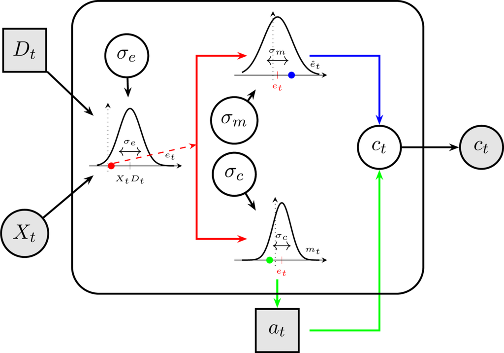

```r
img1 <- image_read_pdf(here::here("Preregistration", "Figure scripts","Platenotations", "platenotation.pdf"),
                       density = 600)

# Optionally trim any remaining whitespace and resize
img1 <- image_trim(img1)
img1 <- image_resize(img1, "1200x")  # Adjust width as needed (height scales proportionally)

print(img1)
```

Figure 1; An agent is presented with a stimulus that has a direction $D_i$ (the true state of the world) and an intensity $X_i$. This creates an internal evidence representation $e_i$ (red point), due to noise in the sensory encoding ($\sigma_e$). This internal evidence representation is then sent to the pre-motor and motor cortex where an efferent signal is produced together with an efference copy (red split path). Due to additional noise($\sigma_c$) in the processing and transmission of the signal to limb generating the action, it is possible that the action generated is in the oppisite side of what the evidence entailed (green point). The efference copy might also be subjected to additional noise ($\sigma_m$), which is then used together with the action to produce a prediction error in the comparator $C_t$. This prediction error is then used to give a confidence ratings $C_t$.

Next we demonstrate simulations from this model to provide an intuition for the meaning of the parameters and their interactions.

### Simulations

Below we demonstrate that the model reproduces key behavioral patterns of choice and confidence ratings under different parameter combinations. Foreshadowing the results, our simulations show that the ratio $\frac{\sigma_e}{\sigma_c}$ determines the main confidence patterns of folded-X or double increase which relate to error-monitoring.

- A low ratio (high $\sigma_c$ low $\sigma_e$) produces folded-X (strong error-monitoring), while a high ratio (low $\sigma_c$ high $\sigma_e$) produces double-increase (weak or no error-monitoring).
- The metacognitive noise $\sigma_m$ flattens the confidence curves regardless of accuracy.

Note: For all simulations below we assume that the bias in evidence encoding $\beta$ is 0. We will get back to this, which relates to the assumption of subjects have access to the objective stimulus intensity.

```r
set.seed(199742)

n_trials <- 500

simulate_interaction <- function(sigma_m, sigma_c,sigma_e) {
  X <- abs(rnorm(n_trials,2,1))
  D <- sample(c(-1, 1), n_trials, replace = TRUE)
  e <- rnorm(n_trials, mean = D * X, sd = sigma_e)
  ehat <- rnorm(n_trials, e, sigma_m)
  k_gauss <- rnorm(n_trials, 0, sigma_c)
  p_gauss <- pnorm(e / sigma_c)
  a <- rbinom(n_trials, 1, p_gauss)

  data.frame(e = e,
             a = a,
             X = X,
             D=D,
             ACC = ifelse(a == 0 & D == -1,1,ifelse(a == 1 & D == 1,1,0)))
}


df_interaction <- expand.grid(
  sigma_m = c(0.1, 0.5 ,1,3, 5),
  sigma_c = c(0.1, 0.5 ,1,3, 5),
  sigma_e = c(0.1, 0.5 ,1,3, 5)

) %>%
  rowwise() %>%
  mutate(data = list(simulate_interaction(sigma_m, sigma_c,sigma_e))) %>%
  unnest(data)
```

First, we might look at the distribution of internal evidence to the objective signed stimulus (i.e. the product of the stimulus intensity and the true state) across the choice parameters.

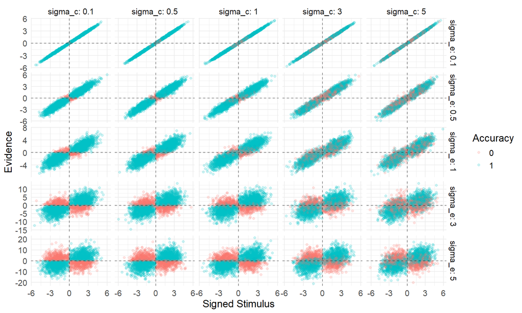

```r
ACC = df_interaction %>%
  mutate(Accuracy = as.factor(ACC)) %>%
  ggplot(aes(x = X*D, y = e, col = Accuracy)) +
  labs(x = "Signed Stimulus", y = "Evidence") +
  geom_point(alpha = 0.2)+
  facet_grid(sigma_e~sigma_c, scales = "free", labeller = label_both)+
  geom_hline(yintercept = 0, linetype = 2, alpha = 0.5)+
  geom_vline(xintercept = 0, linetype = 2, alpha = 0.5)+
  theme_minimal()+
  theme(text = element_text(size = 14))

ACC
```

From the above plot we see that $\sigma_e$ scales the the range of evidence observed, moving down the rows the y-axis greatly changes its range. When $\sigma_c$ is low (left column) choices are consistent (when the the evidence is positive and the signed stimulus is positive (i.e. D = 1), a correct response is given). When $\sigma_c$ increases this relationship essentially becomes more noisy, such that correct and incorrect choices are less distinguishable across the evidence = 0 line.

Another way to display this is by plotting the actions instead of the accuracy:

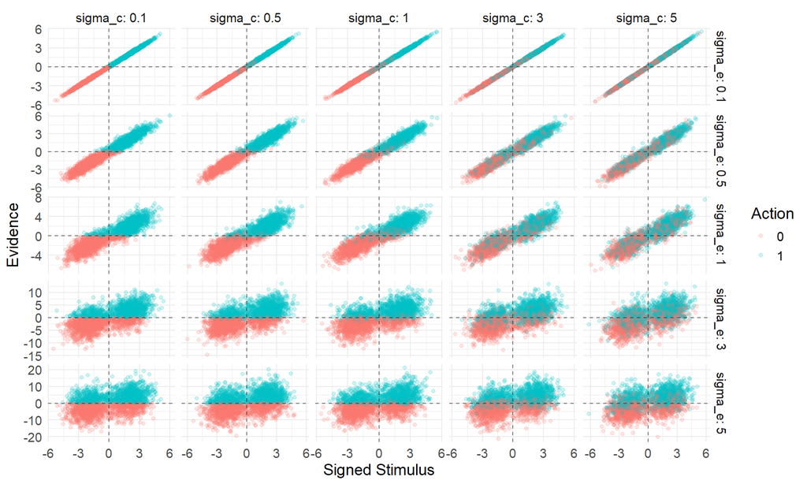

```r
Act = df_interaction %>%
  mutate(Action = as.factor(a)) %>%
  ggplot(aes(x = X*D, y = e, col = Action)) +
  labs(x = "Signed Stimulus", y = "Evidence") +
  geom_point(alpha = 0.2)+
  facet_grid(sigma_e~sigma_c, scales = "free", labeller = label_both)+
  geom_hline(yintercept = 0, linetype = 2, alpha = 0.5)+
  geom_vline(xintercept = 0, linetype = 2, alpha = 0.5)+
  theme_minimal()+
  theme(text = element_text(size = 14))
Act
```

Next we look at the confidence ratings as a function of the three different sigmas.

```r
set.seed(199742)

n_trials <- 5000

conf_prec <- 100
c0 <- -3
c1 <- 3

simulate_interaction <- function(sigma_m, sigma_c,sigma_e) {
  X <- sample(c(0.01,1,2,5), n_trials, replace = TRUE)
  D <- sample(c(-1, 1), n_trials, replace = TRUE)
  e <- rnorm(n_trials, mean = D * X, sd = sigma_e)
  ehat <- rnorm(n_trials, e, sigma_m)
  k_gauss <- rnorm(n_trials, 0, sigma_c)
  p_gauss <- pnorm(e / sigma_c)
  a <- rbinom(n_trials, 1, p_gauss)
  C_mu <- ifelse(a == 1,
                 plogis(2 * ehat * X / (sigma_e^2 + sigma_m^2)),
                 1 - plogis(2 * ehat * X / (sigma_e^2 + sigma_m^2)))


  c_mu <- pmax(0.001, pmin(0.999, C_mu))
  C <- ordbetareg::rordbeta(n_trials, c_mu, conf_prec, c(c0, c1))

  data.frame(e = e,
             C = C,
             C_mu = C_mu,
             ehat = ehat,
             a = a,
             X = X,
             D=D,
             ACC = ifelse(a == 0 & D == -1,1,ifelse(a == 1 & D == 1,1,0)))
}

df_interaction <- expand.grid(
  sigma_m = c(0.1, 0.5 ,1,3, 5),
  sigma_c = c(0.1, 0.5 ,1,3, 5),
  sigma_e = c(0.1, 0.5 ,1,3, 5)

) %>%
  rowwise() %>%
  mutate(data = list(simulate_interaction(sigma_m, sigma_c,sigma_e))) %>%
  unnest(data)
```

First we fix $\sigma_c = 1$ and then we look at how $\sigma_e$ & $\sigma_m$ change confidence ratings as a function of the signed stimulus strength:

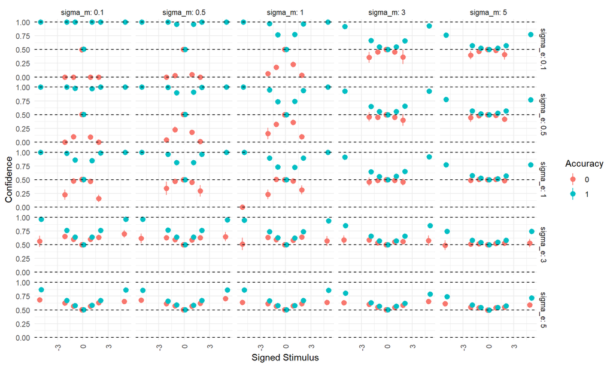

```r
df_interaction %>%
  filter(sigma_c == 1) %>%
  mutate(SS = D*X) %>%
  group_by(SS,ACC, sigma_e,sigma_m) %>%
  summarize(mean = mean(C_mu),
            q5 = mean - 2 * sd(C_mu) / sqrt(n()),
            q95 = mean + 2 * sd(C_mu) / sqrt(n())) %>%
  mutate(Accuracy = as.factor(ACC)) %>%
  ggplot(aes(x = SS, y = mean, ymin = q5, ymax = q95, col = Accuracy)) +
    geom_pointrange(position = position_dodge(width =0.4))+
  facet_grid( sigma_e~ sigma_m, labeller = label_both) +
    geom_hline(yintercept = c(0,0.5,1), linetype = 2)+
  # geom_vline(xintercept = 0, linetype = 2)+
  labs(x = "Signed Stimulus", y = "Confidence") +
  theme_minimal()+
  ylim(c(0,1))+
  theme(axis.text.x = element_text(angle = 90, vjust = 0.5, hjust=1))
```

From the above plot we see that when we plot confidence on the Signed Stimulus scale we end up with a double increase pattern when $\sigma_e$ is high. Furthermore, when $\sigma_e$ is low we see a folded X pattern. Lastly, when meta uncertainty ($\sigma_m$) increase both confidence curves becomes increasingly flat (i.e. closer to a flat line at 0.5) regardless of their correctness.

Next we fix $\sigma_e = 1$ and then we look at $\sigma_c$ & $\sigma_m$:

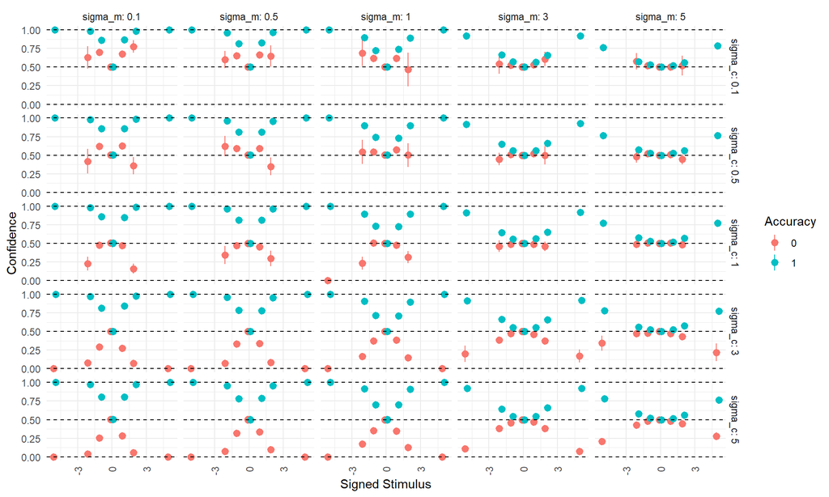

```r
df_interaction %>%
  filter(sigma_e == 1) %>%
  mutate(SS = X*D) %>%
  group_by(SS,ACC, sigma_c,sigma_m) %>%
  summarize(mean = mean(C_mu),
            q5 = mean - 2 * sd(C_mu) / sqrt(n()),
            q95 = mean + 2 * sd(C_mu) / sqrt(n())) %>%
  mutate(Accuracy = as.factor(ACC)) %>%
  ggplot(aes(x = SS, y = mean, ymin = q5, ymax = q95, col = Accuracy)) +
    geom_pointrange(position = position_dodge(width =0.4))+
  facet_grid( sigma_c~ sigma_m, labeller = label_both) +
    geom_hline(yintercept = c(0,0.5,1), linetype = 2)+
  labs(x = "Signed Stimulus", y = "Confidence") +
  theme_minimal()+
  ylim(c(0,1))+
  theme(axis.text.x = element_text(angle = 90, vjust = 0.5, hjust=1))
```

Here we observe a similar patterns as before with $\sigma_c = 1$. Here we have that a high $\sigma_c$ reflects a folded X, whereas lower values (especially below 1) make a double increase.

lastly we might plot $\sigma_m = 1$

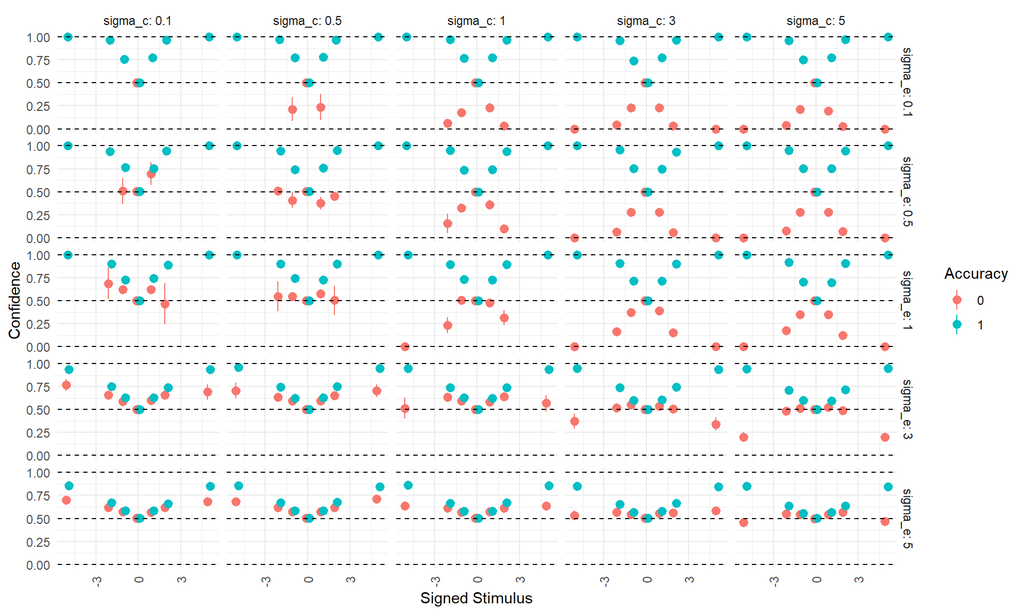

```r
df_interaction %>%
  filter(sigma_m == 1) %>%
  mutate(sigma = sigma_e/sigma_c) %>%
  mutate(SS = X*D) %>%
  group_by(SS,ACC, sigma_c,sigma,sigma_e,sigma_m) %>%
  summarize(mean = mean(C_mu),
            q5 = mean - 2 * sd(C_mu) / sqrt(n()),
            q95 = mean + 2 * sd(C_mu) / sqrt(n())) %>%
  mutate(Accuracy = as.factor(ACC)) %>%
  mutate(sigma_m = as.factor(sigma_m)) %>%
  ggplot(aes(x = SS, y = mean, ymin = q5, ymax = q95, col = Accuracy)) +
    geom_pointrange(position = position_dodge(width =0.4))+
  facet_grid( sigma_e~sigma_c, labeller = label_both) +
    geom_hline(yintercept = c(0,0.5,1), linetype = 2)+
  labs(x = "Signed Stimulus", y = "Confidence") +
  theme_minimal()+
  ylim(c(0,1))+
  theme(axis.text.x = element_text(angle = 90, vjust = 0.5, hjust=1))
```

Here we see that when $\sigma_e = \sigma_c$ (the diagonal), there is a mix between a folded X and a double increase pattern, with incorrect trials being close to 0.5 and independent of stimulus strength. Correct trials increase in confidence across all parameter combinations with stimulus strength. Looking at the upper triangle, where $\sigma_c > \sigma_e$ we see folded-X patterns, whereas in the lower triangle ($\sigma_c < \sigma_e$) we see the opposite pattern, double increase patterns.

These simulations show that from the current model’s perspective, the double increase and Folded-X pattern arise due to different ratios of uncertainty in the encoding and choice. When choice variability is high compared to stimulus encoding, a folded X pattern arises whereas choice variability is low compared to stimulus encoding a double increase pattern arises. Meta uncertainty ($\sigma_m$) is agnostic to the accuracy of the rater and when it increases it makes the confidence curves more flat regardless of correctness.

### Fitting

We want to fit this model using full Bayesian inference with Stan’s NUTS sampler, treating the latent trial-by-trial evidence as parameters estimated jointly with the subject-by-subject noise parameters. Investigating our pilot data we saw that on a single-subject-level this model was possible to fit with sufficiently good sampler diagnostics. However, trying to fit this model in a hierarchical framework (i.e. drawing subject level parameters from group level parameters), we ran into sampling issues. As the current project is going to use a sequential sampling paradigm, a robust and efficient model is necessary. We therefore build a heuristic model that approximates the model shown above, without the need for estimation of trial-by-trial evidence.

### The Heuristic model

While the above model is powerful, its computational complexity (especially in hierarchical settings) motivate a simpler heuristic approximation. The key challenge is that confidence requires trial-specific evidence $r_i$, which cannot be marginalized analytically, because the random variable is inside the inverse logit function.

The inverse logit function and the cumulative normal distribution are in practice close to being indistinguishable up to a constant i.e. $g(.) \sim \Phi(\frac{1}{1.7})$, see plot below:

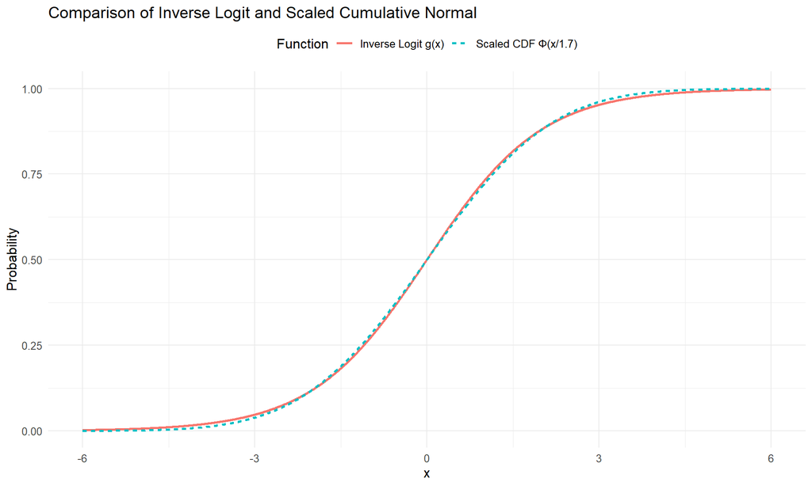

```r
# Compare inverse logit with cumulative normal approximation
data.frame(
  x = seq(-6, 6, by = 0.01)
) %>%
  mutate(
  `Inverse Logit g(x)` = plogis(x),
  `Scaled CDF Φ(x/1.7)` = pnorm(x / 1.7)) %>%
  pivot_longer(cols = -x, names_to = "Function", values_to = "Value") %>%
  ggplot(aes(x = x, y = Value, color = Function, linetype = Function)) +
  geom_line(size = 1) +
  labs(x = "x", y = "Probability",
       title = "Comparison of Inverse Logit and Scaled Cumulative Normal") +
  theme_minimal() +
  theme(text = element_text(size = 12), legend.position = "top")
```

Using this approximation it is possible to marginalize out the trial-by-trial evidence and hereby getting a computationally less expensive model (and an equation for the expectation of confidence) that uses the same parameters.

With this approximation we go from equation (2) to the following:

$$P(\text{correct} \mid r_i, a, X_i) = \begin{cases}\Phi\left(\frac{C
\cdot r_i \cdot X_i}{\sigma_e^2 + \sigma_m^2}\right) & \text{if } a
= 1 \\ 1 - \Phi\left(\frac{C \cdot r_i \cdot X_i}{\sigma_e^2 +
\sigma_m^2}\right) & \text{if } a = -1\end{cases} \tag{3}$$
with $C = \frac{2}{1.7}$.

Focusing on the instance where the choice was one.

$$\Phi\left(\frac{C \cdot r_i \cdot X_i}{\sigma_e^2 + \sigma_m^2}\right)$$

We want to marginalize over $r_i$, meaning that we want to calculate the expectation of above equation, across $r_i$.

This is can be done using the general formula for the expectation of a random continuous variable.

$$\mathbb{E(X)} = \int_{-\infty}^\infty x \ p(x) dx$$

Substituting the variables, with the following $b = \frac{CX_i}{\sigma_e^2 + \sigma_m^2}$

$$\int_{-\infty}^\infty \Phi(b \cdot r_i) \ p(r_i) dr_i$$

with $r_i \sim \mathcal{N}(\mu,\sigma)$

This integral can be shown to have the [solution](https://www.tandfonline.com/doi/abs/10.1080/03610918008812164):

$$\Phi \left(\frac{\mu \cdot b}{\sqrt{1+\sigma^2 \cdot b^2}}\right)$$

Given that we have $r_i \sim \mathcal{N}(X_iD_i - \beta, \sqrt{\sigma_m^2+\sigma_e^2})$, we get:

$$\Phi \left(\frac{\mathbb{E}(r_i) \cdot
b}{\sqrt{1+(\sigma_e^2+\sigma_m^2) \cdot b^2}}\right)$$

Here we write the expectation of $r_i$, instead of the mean of the $r_i$ distribution ($X_iD_i - \beta$), as this will be conditional on the choice (remember we are looking at $a_i = 1$).

Writing it all out and simplify, we get:

$$\Phi\left(\frac{\mathbb{E}(r_i) \cdot CX_i}{ \sigma_e^2 + \sigma_m^2}
\cdot\frac{1} {\sqrt{1 + \frac{C^2X^2_i}{\sigma_e^2+\sigma_m^2}}}\right)$$

This equation thus gives us the probability of being correct, when the choice is 1. Given that the rater knows the choice, we need to get the expectation of meta cognitive evidence ($r_i$) conditional on the choice.

Equation (3), therefore now becomes:
$$P(\text{correct} \mid a, X_i) = \begin{cases}
\Phi\left(\frac{\mathbb{E}(r_i \mid a = 1) \cdot CX_i}{\sigma_e^2 +
\sigma_m^2} \cdot \frac{1}{\sqrt{1 +
\frac{C^2X^2_i}{\sigma_e^2+\sigma_m^2}}}\right) & \text{if } a = 1
\\
1 - \Phi\left(\frac{\mathbb{E}(r_i \mid a = -1) \cdot CX_i}{\sigma_e^2 +
\sigma_m^2} \cdot \frac{1}{\sqrt{1 +
\frac{C^2X^2_i}{\sigma_e^2+\sigma_m^2}}}\right) & \text{if } a = -1
\end{cases} \tag{4}$$

The last step is now to calculate the two expectations of $r_i$ given the choice i.e. $\mathbb{E}(r_i \mid a_i = 1)$ and $\mathbb{E}(r_i \mid a_i = -1)$

#### Calculating conditional expectations

To calculate these expectations, we need to account for the fact that the choice $a_i$ depends on the relationship between the evidence $e_i$ and the criterion $c_i$, and given that $r_i$ is a noisy readout of $e_i$ there is a dependency structure.

We have the following relationships:

- Evidence: $e_i \sim \mathcal{N}(X_iD_i - \beta, \sigma_e)$
- Criterion: $c_i \sim \mathcal{N}(0, \sigma_c)$
- Metacognitive evidence: $r_i = e_i + \epsilon_m$ where $\epsilon_m \sim \mathcal{N}(0, \sigma_m)$
- Choice: $a_i = 1$ if $e_i > c_i$, otherwise $a_i = -1$

we can treat the difference distribution $e_i - c_i$ as a joint bivariate normal distribution with $r_i$ and calculate the expectation of $r_i$ given that the $e_i - c_i$ random variable is above 0 (or equivalently that the choice was 1).

The difference $e_i - c_i$ follows a Gaussian distribution, as both random variables are Gaussian.

$$(e_i - c_i) \sim \mathcal{N}(X_iD_i - \beta, \sqrt{\sigma_e^2 +
\sigma_c^2})$$
The joint bivariate normal distribution becomes:

$$\begin{bmatrix}
e_i - c_i \\
r_i
\end{bmatrix}
\sim \mathcal{N}\left(
\begin{bmatrix}
X_iD_i - \beta \\
X_iD_i - \beta
\end{bmatrix},
\begin{bmatrix}
\sigma_e^2 + \sigma_c^2 & \sigma_e^2 \\
\sigma_e^2 & \sigma_e^2 + \sigma_m^2
\end{bmatrix}
\right)$$

Intuitively this bivariate normal distribution can be argued for by realizing that both distributions of $e_i - c_i$ and $r_i$ share $e_i$, with the same mean but are otherwise independent.

The key mathematical insight is that the covariance between $e_i-c_i$ and $r_i$ is $\sigma_e^2$ and not zero.

Writing the full covariance and expanding it using this we get:

$$\text{Cov}(e_i-c_i, r_i) = \text{Cov}(e_i-c_i, e_i + \epsilon_m)$$
$$\text{Cov}(e_i-c_i, r_i) = \text{Cov}(e_i,e_i) + \text{Cov}(e_i,
\epsilon_m) - \text{Cov}(c_i,e_i) - \text{Cov}(c_i,
\epsilon_m)= \text{Cov}(e_i,e_i) = \text{Var}(e) =\sigma_e^2$$
As $e_i$ and $\epsilon_m$ and also $c_i$ are independent, these covariances are 0:

$$\text{Cov}(e_i-c_i, r_i) = \text{Cov}(e_i,e_i) = \text{Var}(e)
=\sigma_e^2$$

This shared variance structure means that $e_i-c_i$ and $r_i$ are correlated with correlation coefficient.

$$\rho = \frac{\sigma_e^2}{\sqrt{(\sigma_e^2 + \sigma_c^2)} \cdot
\sqrt{(\sigma_e^2 + \sigma_m^2)}} \tag{5}$$

#### Truncated normal distributions

To proceed, we need a general result from probability theory. Suppose we have two jointly normal random variables:

$$\begin{pmatrix} Z \\ Y \end{pmatrix} \sim
\mathcal{N}\left(\begin{pmatrix} \mu_Z \\ \mu_Y \end{pmatrix},
\begin{pmatrix} \sigma_Z^2 & \rho\sigma_Y\sigma_Z \\
\rho\sigma_Y\sigma_Z & \sigma_Y^2 \end{pmatrix}\right)$$
It can be shown that the expectation of Y given Z>0 is:

$$\mathbb{E}(Y \mid Z > 0) = \mu_Y + \rho\cdot
\sigma_Y\frac{\phi(z_z)}{\Phi(z_z)}$$

With $z_Z = \frac{\mu_Z}{\sigma_Z}$

For a full derivation see; Derivation.

Now replacing Y with $r_i$ and Z with $e_i - c_i$ we get:

$$\mathbb{E}(r_i \mid (e_i-c_i) > 0) = (X_iD_i - \beta) + \rho \cdot
\sqrt{\sigma_e^2 + \sigma_m^2} \cdot \frac{\phi(z_z)}{\Phi(z_z)}$$

With $z_z = \frac{X_iD_i - \beta}{\sqrt{\sigma_e^2 + \sigma_c^2}}$

It can then easily be shown using the same steps that when the action is -1 i.e. $(e_i-c_i) < 0$ this becomes:

$$\mathbb{E}(r_i \mid (e_i-c_i) > 0) = (X_iD_i - \beta) - \rho \cdot
\sqrt{\sigma_e^2 + \sigma_m^2} \cdot \frac{\phi(-z_z)}{\Phi(-z_z)}$$

we might define $\lambda(x) = \frac{\phi(x)}{\Phi(x)}$, which is the inverse Mills ratio giving us:

$$\mathbb{E}(r_i \mid a = 1) = (X_iD_i - \beta) + \rho \cdot
\sqrt{\sigma_e^2 + \sigma_m^2} \cdot \lambda\left(\frac{X_iD_i -
\beta}{\sqrt{\sigma_e^2 + \sigma_c^2}}\right)$$

For $a = -1$ (when $e_i - c_i \leq 0$):

$$\mathbb{E}(r_i \mid a = -1) = (X_iD_i - \beta) - \rho \cdot
\sqrt{\sigma_e^2 + \sigma_m^2} \cdot \lambda\left(-\frac{X_iD_i -
\beta}{\sqrt{\sigma_e^2 + \sigma_c^2}}\right)$$
Note that $\lambda(-x) = \frac{\phi(x)}{1-\Phi(x)}$ by properties of the normal distribution.

### Final confidence model

Substituting these conditional expectations back into our marginalized confidence equation (4).

Simplifying.

Interestingly these two stimulus intensities, especially the first one (which is not from the marginalization) serves to make sure that at intensity 0 the predicted confidence will always be 0.5. So not only is it a strong assumption that the agent has access to the objective stimulus strength, this assumption does not even hold given the empirical observation that the lowest confidence rating shifts with the psychometric function which we highlighted in the Models and Data Markdown. From the formalization that confidence ratings reflect a noisy, subjective probability of being correct, incorporating response biases, the above formulation falters as there is an objective anchor at $X_i = 0$.

Due to these consideration, supported by some empirical validation on our pilot data below, we believe that this particular stimulus intensity, coming from an unjustified assumption, needs to be accessed.

One interesting idea of how to deal with this, is to assume that the agent has a noisy readout of the stimulus strength, $\hat{X} \sim p(\hat{x}|\theta,c)$. The problem with such formulation is defining the probability distribution of the internal stimulus intensity. This probability distribution needs to be positively bound as $\hat{X} > 0$, which introduces an abitrary choice, but more importantly makes is non trivial to marginalize the trial-by-trial readout. Another approach would be to replace this stimulus intensity value with a constant, which could vary across subjects. Such parameterization would serve as a placeholder for idosyncratic differences in how subjects might use the stimulus intensity above and beyond what they should have access to.

Instead of opting for these options, we chose to assume that the agents do not have access to this stimulus intensity and therefore fix it to 1. This approach in its simplicity circumvents some of the troublesome computational aspects, as well as obeying to what the agents is assumed to have access to. This also importantly this makes it possible for the model to accommodate the empirical observation that the confidence curve follows the psychometric function of the binary choices.

with:
$$\lambda(x) = \frac{\phi(x)}{\Phi(x)}
\\
C = \frac{2}{1.7}$$

In the above formula it is noteworthy that the terms inside the cumulative normal distribution function have clear interpretations.

Firstly the common factor, is a correction factor for marginalization. thus we define:

$$K_i = \frac{1} {\sqrt{1 + \frac{C^2}{\sigma_e^2+\sigma_m^2}}}$$

The two other terms can be thought to have more cognitive interpretations. Looking back at equation 3 we had (now with $X_i = 1$)

$$P(\text{correct} \mid r_i, a, X_i) = \begin{cases}\Phi\left(\frac{C
\cdot r_i}{\sigma_e^2 + \sigma_m^2}\right) & \text{if } a = 1 \\ 1 -
\Phi\left(\frac{C \cdot r_i}{\sigma_e^2 + \sigma_m^2}\right) &
\text{if } a = -1\end{cases} \tag{3}$$

$$I_i = \mathbb{E}\left(\frac{C \cdot r_i}{\sigma_e^2 + \sigma_m^2}\right)
= \frac{(CX_iD_i - C\beta)}{\sigma_e^2 + \sigma_m^2}$$

The latter term in equation (7a / 7b) adjusts this average evidence strength, because of the information contained by the action selected:
$$S_i = -\rho \cdot \frac{ \lambda\left(-\frac{X_iD_i -
\beta}{\sqrt{\sigma_e^2 + \sigma_c^2}}\right)C}{\sqrt{\sigma_e^2 +
\sigma_m^2} }$$

This term serves the purpose of changing the mean expectation of the confidence to incorporate the information of the action. The addition of actions into the confidence computation have been proposed in the second order rater model from Fleming and Daw, where they also re-analyzed data to show this pattern empirically [@FLEMINGSelfEvaluationDecisionMakingGeneralBayesianFrameworkMetacognitive2017]. To summarize, confidence computation can in this model be thought of as a weighting of the expected normalized evidence with a correction factor for having committed to a choice. Below we introduce a couple of additional parameters in order to encompass idiosyncrasies in the task and participants, as well as probabilistic relate the above formulation to the observed confidence ratings.

#### Additional parameters

We introduce 5 additional parameters. $\Theta_2 = (\kappa_c, \lambda, \mu_{\beta})$.

- $\lambda$ is the lapse rate on the binary choices this is a stimulus independent factor that shifts the asympote of the psychometric function away from certainty i.e. the asymptotic becomes $\lambda$ and $1-\lambda$.
- $\mu_{\beta}$ is a meta cognitive bias parameter, serving as an independent vertical shift of confidence ratings.
- $\kappa_c$ is the precision of the ordered beta likelihood.
- Lastly $c_0,c_1$ reflects the two cutpoints for the ordered beta likelihood. These two parameters help generalize the beta-distribution to outcomes that contain 0 and 1 ratings.

See [@KUBINECOrderedBetaRegressionParsimoniousWellFittingModel2023] for the ordered beta likelihood.

The complete set of parameters for the model are:

$$\Theta_s = \begin{bmatrix}
beta_s \\
\sigma_{e_s} \\
\sigma_{c_s} \\
\sigma_{m_s} \\
\mu_{\beta_s} \\
\kappa_{c_s} \\
\lambda_s
\end{bmatrix}
\sim
\mathcal{N}(\mu_{\Theta},\Sigma_{\Theta})
\\
\beta_s \in [-1,1], \sigma_{e_s} >0, \sigma_{c_s} >0,
\sigma_{m_s} > 0,
\\
\mu_{\beta_s} \in \mathop{\mathbb{R}}, \kappa_{c_s} > 0, \lambda_s
\in [0,0.5]
\\
(c_{1_s} , c_{0_s}) \sim \delta([1,10,1])$$

In the above formulation that $\mathcal{N}$ is a multivariate normal distribution with mean and covariance. Further all constraints on the parameters as written were accomplished by transformation, all positively constrained parameters were exponentiated, parameters with an upper and lower bound were transformed with the inverse logit function and multiplied appropriately. The constraint of the cut-points were applied by the prior of a Dirichlet distribution ($\delta()$). Note, the cutpoints are sampled on a subject-by-subject basis.

The full model becomes.

$$\\
P(a = 1) = \Phi\left(\frac{D_i \cdot X_i- \beta_s}{\sqrt{\sigma_{e_s}^2
+ \sigma_{c_s}^2}}\right)
\\
\mu_{c_i} = \begin{cases}\Phi\left((I_i-S_i)\cdot C_i\right) &
\text{if } a_i = 1
\\
1 - \Phi\left((I_i+S_i)\cdot C_i\right) & \text{if } a_i =
-1\end{cases}
\\
a_i \sim \mathcal{bernoulli}(p(a_i = 1))
\\
Conf_i \sim \mathcal{ord\beta}(\mu_{c_i},\kappa_{c_s},c_{0_s},c_{1_s})$$

Next we show verification of the above formulated marginalized heuristic model, by simulating data from from equation (2) (with $X_i = 1$) averaging across the signed stimulus axis and displaying for the same parameter estimates (i.e. $\Theta_1$) of the marginalized heuristic model.

The In the first validation step we simulate from different combinations of noise parameters (facets).

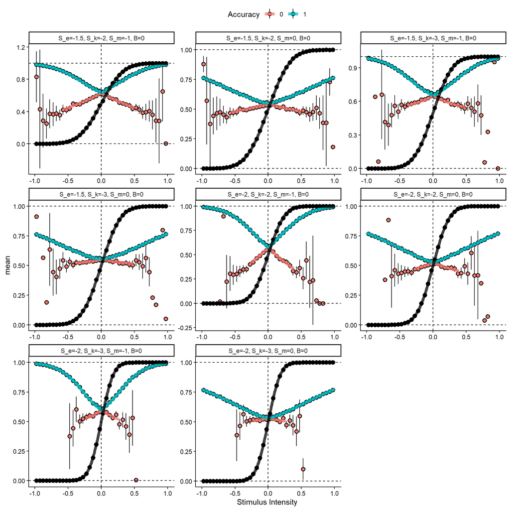

```r
source("~/RDM-metacognition/Preregistration/scripts/Simulation.R")

library(tidyverse)

trials = 500000

# Define high/low values
sigma_e_vals <- c(-2, -1.5)   # example low/high
sigma_k_vals <- c(-3, -2)
sigma_m_vals <- c(-1, 0)


param_grid <- expand.grid(
  sigma_e = sigma_e_vals,
  sigma_k = sigma_k_vals,
  sigma_m = sigma_m_vals,
  bias    = 0  # start with bias = 0 for all
)

# Add an extra row for the one case where bias != 0 (if desired)
param_grid <- param_grid%>%
  mutate(id = row_number())

param_grid <- param_grid %>%
  mutate(facet_label = paste0("S_e=", sigma_e,
                              ", S_k=", sigma_k,
                              ", S_m=", sigma_m,
                              ", B=", bias))

breaks <- seq(-1, 1, by = 0.05)
midpoints <- breaks[-length(breaks)] + 0.1

df_mech = param_grid %>%
    rowwise() %>%
    mutate(sims = list(simulate_data_p_bias(500000, sigma_e = sigma_e, sigma_k = sigma_k, sigma_m = sigma_m, bias = bias, seed = 1))) %>%
    ungroup() %>%
    unnest() %>%
    mutate(XD = X * D,
    bin = cut(XD, breaks = breaks, include.lowest = TRUE, labels = FALSE),
    XD = (breaks[bin] + breaks[bin + 1]) / 2) %>%
  mutate(Action = as.factor(a_gauss),
         Accuracy = as.factor(ACC))

df_heu = param_grid %>%
    rowwise() %>%
    mutate(sims = list(simulate_data_margin_bias(500, sigma_e = sigma_e, sigma_k = sigma_k, sigma_m = sigma_m, bias = bias, seed = 1))) %>%
    ungroup() %>%
    unnest() %>%
    mutate(XD = X*D) %>%
  mutate(bin = NA)%>%
  mutate(Action = as.factor(a_gauss),
         Accuracy = as.factor(ACC))



rbind(df_mech,df_heu) %>% ggplot()+
  geom_pointrange(data = df_mech %>%
                    group_by(XD, Accuracy,facet_label) %>%
                    summarize(mean = mean(c_mu),
                              se = sd(c_mu)/sqrt(n())),
                  aes(x = XD,y = mean,ymin = mean-2*se, ymax = mean+2*se, fill = Accuracy), shape = 21, col = "black")+
  geom_pointrange(data = df_mech %>%
                    group_by(XD, facet_label) %>%
                    summarize(k = sum(as.numeric(as.character(Action))),
                              n = n(),
                              prop = k / n,
                              a_post = k + 1,
                              b_post = (n - k) + 1,
                              lower = qbeta(0.025, a_post, b_post),
                              upper = qbeta(0.975, a_post, b_post)),
                  aes(x = XD,y = prop,ymin = lower, ymax = upper), col = "black", shape = 21,fill = "black")+
  geom_line(data = df_heu, aes(x = XD,y = c_mu, col = Accuracy), linewidth = 2, alpha = 0.75)+
  geom_line(data = df_heu, aes(x = XD,y = p_gauss), linewidth = 2, alpha = 0.75, col = "black")+
  theme_classic()+
  facet_wrap(~facet_label, scales = "free") +
  labs(x = "Stimulus Intensity")+
  geom_vline(xintercept = 0, linetype = 2)+
  geom_hline(yintercept = 0, linetype = 2)+
  geom_hline(yintercept = 1, linetype = 2)+
  theme(legend.position = "top")
```

Next we simulate using fixed noise parameters and change the bias $\beta$. Note, that now we are displaying the action and not the accuracy of the choice.

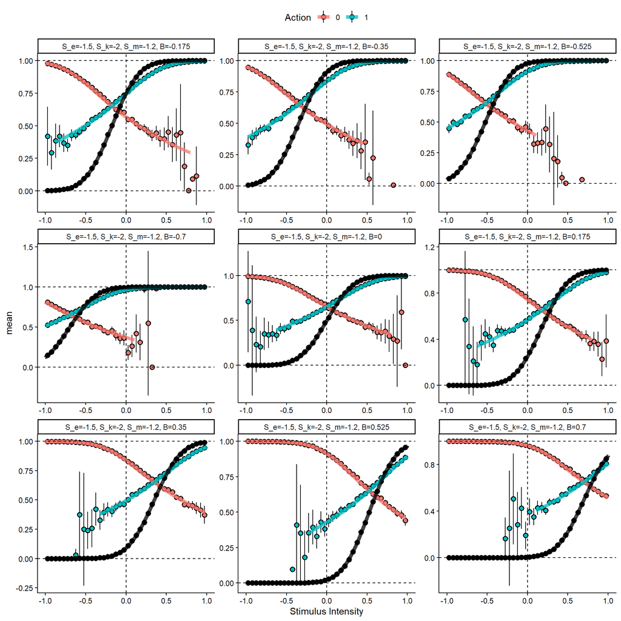

```r
# Define high/low values
sigma_e_vals <- c(-1.5)   # example low/high
sigma_k_vals <- c(-2)
sigma_m_vals <- c(-1.2)


param_grid <- expand.grid(
  sigma_e = sigma_e_vals,
  sigma_k = sigma_k_vals,
  sigma_m = sigma_m_vals,
  bias    = seq(-0.7,0.7,length.out = 9)
)

# Add an extra row for the one case where bias != 0 (if desired)
param_grid <- param_grid%>%
  mutate(id = row_number())

param_grid <- param_grid %>%
  mutate(facet_label = paste0("S_e=", sigma_e,
                              ", S_k=", sigma_k,
                              ", S_m=", sigma_m,
                              ", B=", bias))

breaks <- seq(-1, 1, by = 0.05)
midpoints <- breaks[-length(breaks)] + 0.1

df_mech = param_grid %>%
    rowwise() %>%
    mutate(sims = list(simulate_data_p_bias(500000, sigma_e = sigma_e, sigma_k = sigma_k, sigma_m = sigma_m, bias = bias, seed = 1))) %>%
    ungroup() %>%
    unnest() %>%
    mutate(XD = X * D,
    bin = cut(XD, breaks = breaks, include.lowest = TRUE, labels = FALSE),
    XD = (breaks[bin] + breaks[bin + 1]) / 2) %>%
  mutate(Action = as.factor(a_gauss),
         Accuracy = as.factor(ACC))

df_heu = param_grid %>%
    rowwise() %>%
    mutate(sims = list(simulate_data_margin_bias(5000, sigma_e = sigma_e, sigma_k = sigma_k, sigma_m = sigma_m, bias = bias, seed = 1))) %>%
    ungroup() %>%
    unnest() %>%
    mutate(XD = X*D) %>%
  mutate(bin = NA)%>%
  mutate(Action = as.factor(a_gauss),
         Accuracy = as.factor(ACC))



rbind(df_mech) %>% ggplot()+
  geom_pointrange(data = df_mech %>%
                    group_by(XD, Action,facet_label) %>%
                    summarize(mean = mean(c_mu),
                              se = sd(c_mu)/sqrt(n())),
                  aes(x = XD,y = mean,ymin = mean-2*se, ymax = mean+2*se, fill = Action), shape = 21, col = "black")+
  geom_pointrange(data = df_mech %>%
                    group_by(XD, facet_label) %>%
                    summarize(k = sum(as.numeric(as.character(Action))),
                              n = n(),
                              prop = k / n,
                              a_post = k + 1,
                              b_post = (n - k) + 1,
                              lower = qbeta(0.025, a_post, b_post),
                              upper = qbeta(0.975, a_post, b_post)),
                  aes(x = XD,y = prop,ymin = lower, ymax = upper), shape = 21, col = "black",fill = "black")+
  geom_line(data = df_heu, aes(x = XD,y = c_mu, col = Action), linewidth = 2, alpha = 0.75)+
  geom_line(data = df_heu, aes(x = XD,y = p_gauss), linewidth = 2, alpha = 0.75, col = "black")+
  theme_classic()+
  facet_wrap(~facet_label, scales = "free") +
  geom_vline(xintercept = 0, linetype = 2)+
  geom_hline(yintercept = 0, linetype = 2)+
  geom_hline(yintercept = 1, linetype = 2)+
  labs(x = "Stimulus Intensity")+
  theme(legend.position = "top")
```

## Model comparison

```r
model_with_x <- readRDS(here::here("Experimental analysis","Heurestic models",
                                   "saved models","saved models hier","fit_finalheu_lapse_cypertron.rds"))


model_with_x1 <- readRDS(here::here("Experimental analysis","Heurestic models",
                                    "saved models","saved models hier","fit_finalheu_lapse_x1.rds"))

loocomparison = loo::loo_compare(list(with_x = model_with_x$loo(), with_x1 = model_with_x1$loo()))
```

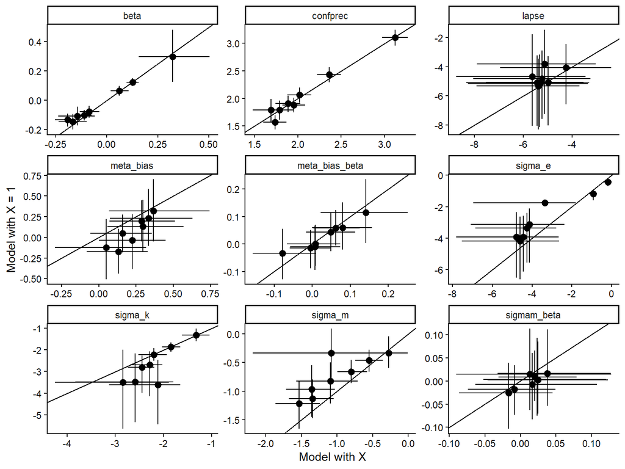

```r
parameters = c("beta","sigma_e","sigma_k","sigma_m","confprec","lapse","meta_bias","confprec","meta_bias_beta","sigmam_beta")


rbind(
    model_with_x$summary(parameters) %>%
      mutate(
        subject  = as.numeric(str_extract(variable, "(?<=\\[)\\d+(?=\\])")),
        variable = str_remove(variable, "\\[\\d+\\]"),
        model    = "X"
      ),

    model_with_x1$summary(parameters) %>%
        mutate(
        subject  = as.numeric(str_extract(variable, "(?<=\\[)\\d+(?=\\])")),
        variable = str_remove(variable, "\\[\\d+\\]"),
        model    = "Xone"
      )
    )%>% select(variable,model,mean,q5,q95) %>%
      pivot_wider(names_from = "model",values_from = c("mean","q5","q95")) %>% unnest() %>%
  ggplot(aes(x = mean_X, y = mean_Xone))+
  geom_pointrange(aes(ymin = q5_Xone, ymax = q95_Xone))+
  geom_pointrange(aes(xmin = q5_X, xmax = q95_X))+
  facet_wrap(~variable, scales = "free")+
  labs(y = "Model with X = 1", x = "Model with X")+
  geom_abline()+
  theme_classic()
```

Generally the two models align well in their subject level parameter estimates, further justifying this simplification which makes theoretical sense.

Next we show predictive checks of the Hierarchical Heurestic model for our pilot participants.

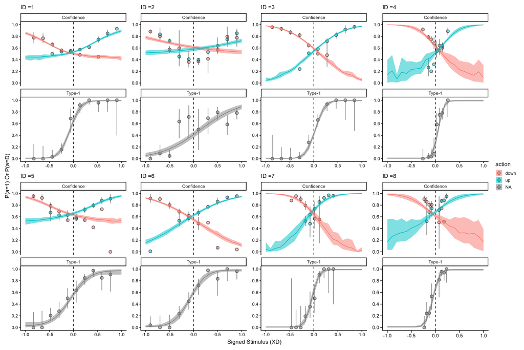

```r
magick::image_read(here::here("Preregistration","Figures","Pilot_predictive_checks.PNG"))
```

### Hierarchical parameter recovery

To further robustness check our implementation of the model as well as the planned sequential sampling, we simulated new subjects from the posterior distribution of the hierarchical model. We did this by extracting a draw from the posterior and then simulating 25 subjects from this draw. We then fitted the model to increasing steps (i.e. 5,7,9, 12,15,20,25) of subjects, to demonstrate that the sequential sampling approach would be feasible. This also allowed us to do parameter recovery on the hierarchical model without additional computational resources. Below we showcase that the model can to an adequate degree recover its parameters on a subject and group level for parameters of interest.

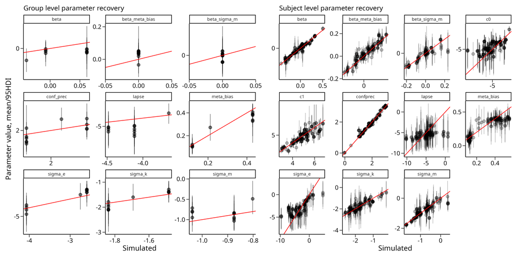

```r
magick::image_read(here::here("Preregistration","Figures","parameterrecovery_hier.PNG"))
```